# Available sebastes samples

Updated October 2022 to hand off to Claire Tobin who is organizing samples, metadata, and performing extractions and genotyping.

Taking a look at data from Ali Deary (EcoFOCI).

```r
library(tidyverse)
library(Rcpp)
library(marmap)
library(hablar)
library(gridExtra)
library(sf)
library(sp)
library(adehabitatHR)
rockfish_df <- readxl::read_xlsx("../data/genetics_rockfish_specimen_list.xlsx", sheet = 2) %>%
  rename(lat = Lat., lon = Long.)
```

```r
devtools::install_github("ropensci/rnaturalearthdata")
install.packages("rnaturalearthhires",
                 repos = "http://packages.ropensci.org",
                 type = "source")
```

[output not shown]

I think the variables that I want to play with are: Year Month Station Number

The Max.Gear.Depth and Bottom.Depth could also be interesting, but maybe will be correlated to the Station?

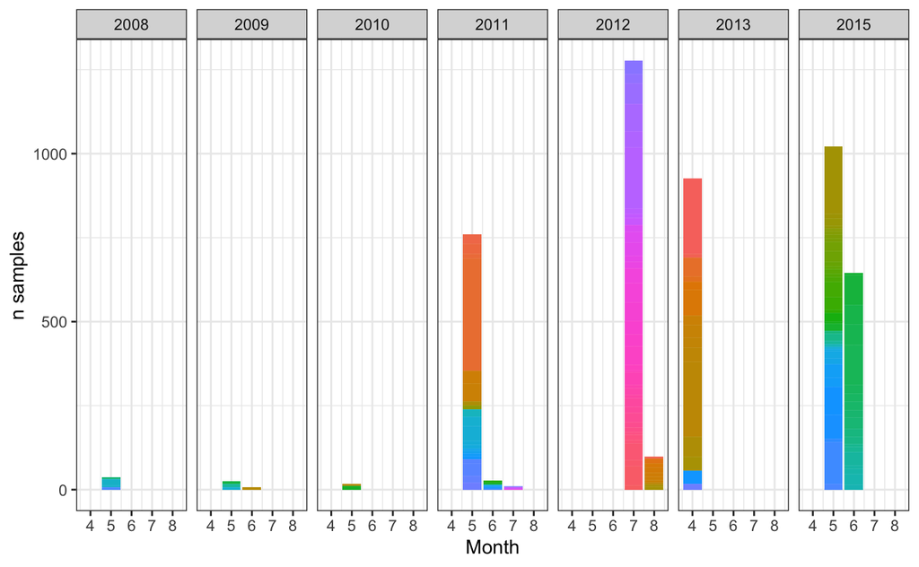

```r
rockfish_df %>%
  dplyr::select(Year, Month, Station, Number) %>%
  ggplot() +
  geom_bar(aes(x = Month, y = Number, fill = Station), stat = "identity") +
  facet_grid(cols = vars(Year)) +
  guides(fill = F) +
  theme_bw() +
  ylab("n samples")
```

Maybe there’s binning that could happen, both at the temporal level (months 4-5 vs. 7-8, e.g.) and at the spatial level, depending on station locations?

```r
rockfish_df %>%
  dplyr::select(Year, Month, Station, Number) %>%
  group_by(Station) %>%
  add_tally(name = "n_samples_per_station")
```

| Year | Month | Station | Number | n_samples_per_station |
| --- | --- | --- | --- | --- |
| 2008 | 5 | 9 | 7 | 2 |
| 2008 | 5 | 23 | 6 | 2 |
| 2008 | 5 | 34 | 18 | 1 |
| 2008 | 5 | 35 | 6 | 1 |
| 2009 | 5 | 22 | 9 | 1 |
| 2009 | 5 | 25 | 9 | 2 |
| 2009 | 5 | 36 | 8 | 2 |
| 2009 | 6 | 131 | 7 | 1 |
| 2010 | 5 | 21 | 11 | 2 |
| 2010 | 5 | 132 | 6 | 1 |

[output cut: 153 more lines]

```r
# unfortunately, there are no more than 2 samples per station

# let's look at the spatial distribution of stations?
```

## Working with spatial data

https://www.r-spatial.org/r/2018/10/25/ggplot2-sf.html

```r
library("ggplot2")
theme_set(theme_bw())
library("sf")

library("rnaturalearth")
library("rnaturalearthdata")

world <- ne_countries(scale = "medium", returnclass = "sf")
class(world)
```

```
[1] "sf"         "data.frame"
```

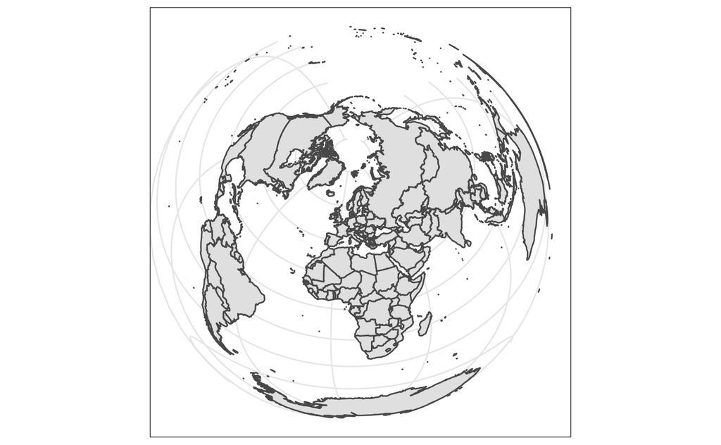

```r
ggplot(data = world) +
    geom_sf() +
    coord_sf(crs = "+proj=laea +lat_0=52 +lon_0=10 +x_0=4321000 +y_0=3210000 +ellps=GRS80 +units=m +no_defs ")
```

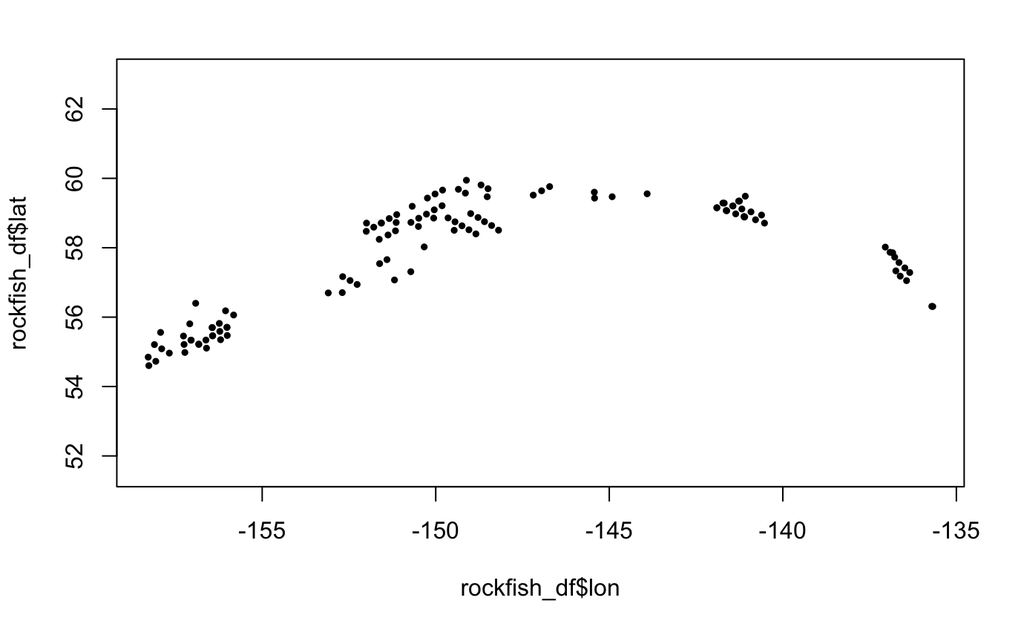

```r
#plot stations lat/lon
plot(rockfish_df$lon, rockfish_df$lat, asp = 1, cex = 0.5, pch = 19)
```

```r
NA
```

```r
# antimeridian region
aleu <- getNOAA.bathy(175, -135, 50, 65, resolution = 4,
antimeridian = TRUE)
```

```
Querying NOAA database ...
This may take seconds to minutes, depending on grid size
Building bathy matrix ...
```

```r
# Make it a raster
bathy <- as.raster(aleu)

# Create a xyz table for ggplot
bath<-fortify(aleu)
```

```r
library(oce)
library(ocedata)
data("coastlineWorldFine")

# convert bathymetry
bathyLon = as.numeric(rownames(aleu))
bathyLat = as.numeric(colnames(aleu))
bathyZ = as.numeric(aleu)
dim(bathyZ) = dim(aleu)

#filter NAs
rockfish_spatial_df <- rockfish_df %>%
  filter(!is.na(lon))

# define plotting region
mlon = mean(rockfish_spatial_df$lon)
mlat = mean(rockfish_spatial_df$lat)
span = 2000
```

Plot it up

```r
# set colors to the Station identity
rockfish_spatial_df %>%
  dplyr::select(Station) %>%
  unique()
```

| Station |
| --- |
| 9 |
| 23 |
| 34 |
| 35 |
| 22 |
| 25 |
| 36 |
| 131 |
| 21 |
| 132 |

[output cut: 91 more lines]

```r
library(RColorBrewer)
# Define the number of colors you want
nb.cols <- 101
mycolors <- colorRampPalette(brewer.pal(8, "Set2"))(nb.cols)
# Create a ggplot with 101 colors
```

```r
# generic AK map
pdf("pdf_outputs/AK_map.pdf", width = 10, height = 8)
# plot station locations
plot(coastlineWorldFine, clon = mlon-5, clat = mlat, span = 2500,
     projection="+proj=aea +lat_1=55 +lat_2=65 +lat_0=50 +lon_0=-154", col = 'lightgrey')

# plot bathymetry
mapContour(bathyLon, bathyLat, bathyZ,
           levels = c(-500, -1000, -2500),
           lwd = c(1.5, 1, 1),
           lty = c(3, 1, 3),
           col = 'darkgray')

# add depth legend
#legend("topright", seg.len = 3, cex = 0.7,
#        lwd = c(1.5, 1, 1),
#        lty = c(3, 1, 3),
#        legend = c("-500", "-1000", "-2500"),
#        box.col = "white", col = 'darkgray', title = "Depth (m)", bg = "white")

# add map data
# add colony locations
# mapPoints(longitude = rockfish_spatial_df$lon, latitude = rockfish_spatial_df$lat, pch = 19, col = mycolors, cex = 0.5, lwd = 2)
#text(longitude = rockfish_spatial_df$lon, latitude = rockfish_spatial_df$lat, rockfish_spatial_df$Station, pos=4)

dev.off()
```

```r
# set up the output
pdf("pdf_outputs/station_map.pdf", width = 8, height = 6)

# plot station locations
plot(coastlineWorldFine, clon = mlon, clat = mlat, span = 1100,
     projection="+proj=aea +lat_1=55 +lat_2=65 +lat_0=50 +lon_0=-154", col = 'lightgrey')

# plot bathymetry
mapContour(bathyLon, bathyLat, bathyZ,
           levels = c(-500, -1000, -2500),
           lwd = c(1.5, 1, 1),
           lty = c(3, 1, 3),
           col = 'darkgray')

# add depth legend
#legend("topright", seg.len = 3, cex = 0.7,
#        lwd = c(1.5, 1, 1),
#        lty = c(3, 1, 3),
#        legend = c("-500", "-1000", "-2500"),
#        box.col = "white", col = 'darkgray', title = "Depth (m)", bg = "white")

# add map data
# add colony locations
mapPoints(longitude = rockfish_spatial_df$lon, latitude = rockfish_spatial_df$lat, pch = 19, col = mycolors, cex = 0.5, lwd = 2)
#text(longitude = rockfish_spatial_df$lon, latitude = rockfish_spatial_df$lat, rockfish_spatial_df$Station, pos=4)

dev.off()
```

Save that map as an object to add to my grid?

```r
# grid libraries
library(gridExtra)
library(gridGraphics)
library(grid)

# plot station locations
plot(coastlineWorldFine, clon = mlon, clat = mlat, span = 1100,
     projection="+proj=aea +lat_1=55 +lat_2=65 +lat_0=50 +lon_0=-154", col = 'lightgrey')

# plot bathymetry
mapContour(bathyLon, bathyLat, bathyZ,
           levels = c(-500, -1000, -2500),
           lwd = c(1.5, 1, 1),
           lty = c(3, 1, 3),
           col = 'darkgray')
```

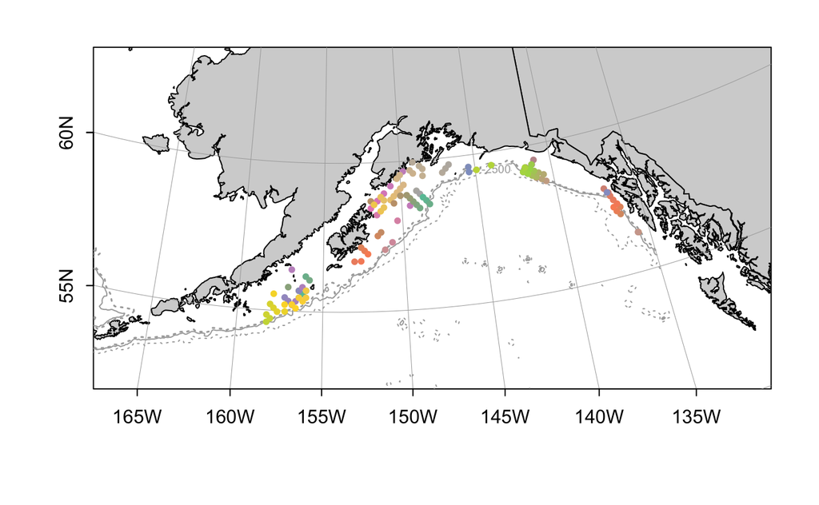

```r
# add locations
mapPoints(longitude = rockfish_spatial_df$lon, latitude = rockfish_spatial_df$lat, pch = 19, col = mycolors, cex = 0.5, lwd = 2)
```

```r
# to save as an object
grid.echo()
```

```r
map.fig <- grid.grab()
```

```r
rockfish_spatial_df %>%
  ggplot() +
  geom_point(aes(x = lon, y = lat, color = Station)) +
  #geom_text(aes(x = lon, y = lat, label = Station)) +
  ggrepel::geom_text_repel(aes(x = lon, y = lat, label = Station)) +
  guides(color = F)
```

[output not shown]

How to create defined clusters from this data?

https://rpubs.com/aephidayatuloh/clustervisual

```r
# kmeans method

rock_cluster <- rockfish_spatial_df %>%
  dplyr::select(lat, lon)

cls <- kmeans(x = rock_cluster, centers = 6)
rock_cluster$cluster <- as.character(cls$cluster)
head(rock_cluster)
```

| lat | lon | cluster |
| --- | --- | --- |
| 55.58850 | -156.2210 | 3 |
| 55.70567 | -156.0133 | 3 |
| 56.18300 | -156.0552 | 3 |
| 56.06133 | -155.8227 | 3 |
| 55.46133 | -156.4318 | 3 |
| 55.80733 | -157.0865 | 3 |

```r
ggplot() +
  geom_point(data = rock_cluster,
             mapping = aes(x = lon,
                                  y = lat,
                                  colour = cluster))
```

[output not shown]

http://www.supplychaindataanalytics.com/proximity-based-spatial-customer-grouping-in-r/

Use K-means clustering, but first define starting points based on the longitude dimensions of the spatial dataset

```r
# define a fct
initial_centers <- function(stations,centers){
  quantiles <- c()
  for(i in 1:centers){
    quantiles <- c(quantiles,i*as.integer(nrow(stations)/centers))
  }
  quantiles
}
```

```r
cluster_obj <- kmeans(rock_cluster,centers=rock_cluster[initial_centers(rock_cluster,6),])
head(cluster_obj)
```

```
$cluster
  [1] 4 4 4 4 4 4 4 6 4 6 1 1 1 1 1 1 1 1 1 1 3 3 3 3 3 3 3 3 5 5 1 4 2 4 4 4 4 4 5 5 6 6 6 6 6 6 6 6 1 3 3 3 3 3 3 3 3 3
 [59] 3 3 3 3 3 2 2 2 2 2 2 2 2 2 4 4 4 4 4 4 6 6 6 6 6 6 6 6 5 5 5 5 5 5 5 5 5 5 5 5 5 5 5 5 5 5 5 5 5 5 5 5 6 6 6 6 6 6
[117] 6 6

$centers
       lat       lon  cluster
1 57.32781 -136.5196 1.166667
2 55.06448 -157.7964 3.000000
3 59.13116 -141.5674 5.000000
4 55.59851 -156.4642 3.000000
5 59.19092 -148.7016 4.000000
6 58.12878 -151.4534 6.000000

$totss
[1] 5768.803

$withinss
[1]  7.199146  2.401540 22.379691  5.147880 51.062216 30.769414

$tot.withinss
[1] 118.9599

$betweenss
[1] 5649.843
```

```r
result_df <- rock_cluster
result_df$group <- cluster_obj$cluster
head(result_df)
```

| lat | lon | cluster | group |
| --- | --- | --- | --- |
| 55.58850 | -156.2210 | 3 | 4 |
| 55.70567 | -156.0133 | 3 | 4 |
| 56.18300 | -156.0552 | 3 | 4 |
| 56.06133 | -155.8227 | 3 | 4 |
| 55.46133 | -156.4318 | 3 | 4 |
| 55.80733 | -157.0865 | 3 | 4 |

```r
result_df <- result_df %>%
  convert(., chr(group))
```

```r
grp_rockfish_df <- result_df %>%
  left_join(., rockfish_spatial_df, by = c("lat", "lon"))

station_locs_plot <- grp_rockfish_df %>%
  ggplot() +
  geom_point(aes(x = lon, y = lat, color = group)) +
  #geom_text(aes(x = lon, y = lat, label = Station)) +
 ggrepel::geom_text_repel(aes(x = lon, y = lat, label = Station)) +
  #guides(color = F)
  ylab("Latitude") +
  xlab("Longitude") +
  theme(
    legend.position = "top"
  )

station_locs_plot
```

[output not shown]

What about by month?

```r
# make month a factor
grp_rockfish_df$Month <- factor(grp_rockfish_df$Month)

# count the data
count_data = count(grp_rockfish_df, Month, group, Year, Number)
# fill in the missing combination
count_data = complete(count_data, Month, group, Year, Number)
# plot the data
ggplot(count_data, aes(x = Month, y = Number, fill = group)) +
  geom_bar(stat = "identity", position = "dodge") +
  facet_grid(rows = vars(Year)) +
  guides(fill = F)
```

[output not shown]

```r
count_data %>%
  arrange(Year)
```

| Month | group | Year | Number | n |
| --- | --- | --- | --- | --- |
| 4 | 1 | 2008 | 3 | NA |
| 4 | 1 | 2008 | 4 | NA |
| 4 | 1 | 2008 | 5 | NA |
| 4 | 1 | 2008 | 6 | NA |
| 4 | 1 | 2008 | 7 | NA |
| 4 | 1 | 2008 | 8 | NA |
| 4 | 1 | 2008 | 9 | NA |
| 4 | 1 | 2008 | 10 | NA |
| 4 | 1 | 2008 | 11 | NA |
| 4 | 1 | 2008 | 12 | NA |

[output cut: 990 more lines]

Now, the thing to do is combine this panel with the map so that the station group locations are evident.

https://cran.r-project.org/web/packages/egg/vignettes/Ecosystem.html

```r
panel <- grid.arrange(samples_mo_yr_station_facet, station_locs_plot, nrow = 2)
```

[output not shown]

```r
ggsave(panel, file = "pdf_outputs/station_grps_panel.pdf", height = 10, width = 6)
```

Now use the map in addition?

```r
# add the map as well
panel3 <- grid.arrange(samples_mo_yr_station_facet, station_locs_plot, map.fig, nrow = 3)
```

```r
ggsave(panel3, file = "pdf_outputs/station_grps_panel3.pdf", height = 10, width = 6)
```

This can be refined by: 1. modifying the colors/groups to display in the map 2. adding labels to the map rather than using the plot?